# Capitalone Data Challenge

##### Functions for interactive visualisations:

```python
#Function to plot business summary of top n parent institutions for a particular year:
def plotParentSummaryyear(masterdata, year, top):

    #Summarising the master data
    summary = parentSummary(masterdata)
    summary = summary.sort(['year', 'state', 'prcnttotalamountlent'], ascending = [1,1,0])
    summary = summary.groupby(['year', 'state']).head(top)
    summary.reset_index(inplace = True)

    #filtering for the concerned year
    df = summary[summary.year == year]

    #adjusting the units and passing columns as plot attributes such as size and brightness of the scatter
    df.noofloans = df.noofloans/1000
    df.alphas = 0.85*df.noofloans/max(df.noofloans)
    df.sizes =  40*df.medianloanamount/max(df.medianloanamount)

    #Datasource for the bokeh glyph
    source = ColumnDataSource(data = dict(
        x = list(df.state),
        y = list(df.prcnttotalamountlent),
        sizes = list(df.sizes),
        alphas = list(df.alphas),
        noofloans = list(df.noofloans),
        parent = list(df.parent_Institution),
        medianloanamount = list(df.medianloanamount),))

    #Hover tool for tooltip
    hover = HoverTool(tooltips=[("Institution:", "@parent"),
                                    ("Marketshare: ", "@y"),
                                    ("Median_loan_amount (in USD 1000s): ", "@medianloanamount"),
                                    ("Noofloans (in 1000s):", "@noofloans"),
                                    ])

    hover.point_policy = "follow_mouse"

    #Declaring figure dimensions, title, xlabel, ylabel etc.,
    p = figure(title='Market Share of top Institutions',
           x_range=list(set(df.state)), x_axis_label = "State", y_axis_label = "Percentage of amount lent in that state",
           tools = [hover], plot_height = 300, plot_width = 800)
    #Circular glyph
    r = p.circle(y = 'y', x = 'x', size = 'sizes', color = 'blue', alpha = 'alphas', source = source)

    return p,r


#Function for plotting county heatmap showing distribution of various parameters across the
#counties for a particular year

def countymap(column, year):

    #importing latitude, longitude and names of counties and states under consideration
    state_xs = [states[code]["lons"] for code in states if code in ['DC','DE','MD', 'VA', 'WV']]
    state_ys = [states[code]["lats"] for code in states if code in ['DC','DE','MD', 'VA', 'WV']]
    county_xs=[counties[code]["lons"] for code in counties if counties[code]["state"] in ['dc','de','md', 'va', 'wv']]
    county_ys=[counties[code]["lats"] for code in counties if counties[code]["state"] in ['dc','de','md', 'va', 'wv']]

    #Converting all names to lower to match with the names in our home loans data
    for code in counties:
        counties[code]["name"] = counties[code]["name"].lower()

    county_name = [counties[code]["name"] for code in counties if counties[code]["state"] in ['dc','de','md', 'va', 'wv']]
    state_name = [counties[code]["state"] for code in counties if counties[code]["state"] in ['dc','de','md', 'va', 'wv']]

    #Getting values of variable under consideration:
    rate = mapsummary(column, year)

    palette.reverse()
    #Passing data source to glypgh
    source = ColumnDataSource(data=dict(
    x=county_xs,
    y=county_ys,
    name=county_name,
    sname = state_name,
    rate=rate,))

    #Tooltip declaration
    hover = HoverTool(tooltips = [
    ("County: ", "@name"),
    ("State: ", "@sname"),
    ("variable: ","@rate"),])
    hover.point_policy = "follow_mouse"

    #Declaring figure details
    p = figure(
    title="County Map", plot_width = 800, plot_height = 500,
    x_axis_location=None, y_axis_location=None, tools = [hover])

    #No grid as we are plotting on a map
    p.grid.grid_line_color = None

    #Color coding the variable under consideration
    color_mapper = LogColorMapper(palette=palette)

    #Patches glyph to draw counties using boundries defined by the list of latitudes and longitudes for each county
    r = p.patches('x', 'y', source=source,
          fill_color={'field': 'rate', 'transform': color_mapper},
          fill_alpha=0.7, line_color="white", line_width=0.5)

    return p,r


#Update functions to update the graph
def update1(year = 2012, top =5):

    summary = parentSummary(masterdata)
    summary = summary.sort(['year', 'state', 'prcnttotalamountlent'], ascending = [1,1,0])
    summary = summary.groupby(['year', 'state']).head(top)
    summary.reset_index(inplace = True)

    df = summary[summary.year == year]
    df.noofloans = df.noofloans/1000
    df.alphas = 0.85*df.noofloans/max(df.noofloans)
    df.sizes =  40*df.medianloanamount/max(df.medianloanamount)

    r1.data_source.data['x'] = list(df.state)
    r1.data_source.data['y'] = list(df.prcnttotalamountlent)
    r1.data_source.data['sizes'] = list(df.sizes)
    r1.data_source.data['alphas'] = list(df.alphas)
    r1.data_source.data['noofloans'] = list(df.noofloans)
    r1.data_source.data['parent'] = list(df.parent_Institution)
    r1.data_source.data['medianloanamount'] = list(df.medianloanamount)

    push_notebook()



def update2(year = 2012, column = "totalloanamount"):
    rate1 = mapsummary(column, year)
    r.data_source.data['rate'] = rate1

    push_notebook()

#Function to convert variable in string format to integer while replacing missing values with -99999999999:
def str_to_int(i, j):
    try:
        return int(i)
    except:
        return j
```

##### Required modules:

```python
import pandas as pd
import matplotlib.pyplot as plt
import numpy as np

import math
import sklearn as sk
import collections

import seaborn as sns
import bokeh
from bokeh import mpl
from bokeh.sampledata.us_counties import data as counties
from bokeh.sampledata.us_states import data as states
from bokeh.plotting import figure, ColumnDataSource,show
from bokeh.charts import Scatter, Bar, BoxPlot, Histogram
from bokeh.io import output_notebook, push_notebook, gridplot, show
from bokeh.models import HoverTool, Range1d, LabelSet, LogColorMapper, CustomJS, ColumnDataSource, Slider
from bokeh.layouts import column, gridplot, row
from bokeh.palettes import Greens9 as palette

from ipywidgets import interact
import warnings
from collections import Counter
import copy
```

```python
#Running other python scripts containing functions to clean data and plot for exploratory analysis:
%run functions.py
```

Introduction:

```
The following analysis is carried out on the home loan data published by Federal Financial Institutions Examination Council. This data consists of two data sets:

1) "2012_to_2014_loans_data":
        This data set contains information about the home loans as reported by the lending institution to the reporting agency for the years 2012 to 2014 within the states where "Change Financial" operates. The data describes various characteristics of the home loan such as loan type, loan purpose, loan amount, applicant income, state, county, government coverage (if any) etc., This data has been filtered to contain only 1-4 family, owner-occupied home loans with an "originated" action type and that were secured by a first or subordinate lien. Description of few important variables of the dataset are as follows:

   * MSA_MD_Description - Description of MSA/MD (Metropolitan Statistical Area (MSA)/Metropolitan Division (MD)
   * FFIEC_Median_Family_Income - Median family income for the MSA/MD in which the census tract is located
   * Number_of_Owner_Occupied_Units - Number of units, in the census tract in which the owner lives
   * Conforming_Limit_000 - Single Unit Conforming Loan limit for the given county
   * Loan_Type_Description - Specifies whether the loan was "conventional," i.e., not backed by a government
   * Applicant_Income_000 - The total income used for decisioning the loan
   * Lien_Status_Description -  If first lien position - least risk. Subordinate liens carry more risk


2) "2012_to_2014_Institutions_data":
        This data set contains the information about the lending institutions such as the state, county and     parent corporation etc.,
```

```python
warnings.filterwarnings('ignore')

loan = pd.read_csv('2012_to_2014_loans_data.csv')
ins = pd.read_csv('2012_to_2014_institutions_data.csv')

#Data obtained by joining loans and ins datasets
masterdata = pd.read_csv("masterdata.csv")
```

```python
##Glimpse of the data:
loan.isnull().sum()
```

```
Agency_Code                           0
Applicant_Income_000                  0
As_of_Year                            0
Census_Tract_Number                   0
County_Code                           0
FFIEC_Median_Family_Income            0
Loan_Amount_000                       0
MSA_MD                                0
Number_of_Owner_Occupied_Units        0
Respondent_ID                         0
Sequence_Number                       0
State_Code                            0
Tract_to_MSA_MD_Income_Pct          900
MSA_MD_Description                95217
Loan_Purpose_Description              0
Agency_Code_Description               0
Lien_Status_Description               0
Loan_Type_Description                 0
State                                 0
County_Name                         837
Conforming_Limit_000                837
Conventional_Status                   0
Conforming_Status                     0
Conventional_Conforming_Flag          0
dtype: int64
```

```python
ins.isnull().sum()
```

```
As_of_Year                 0
Respondent_ID              0
Agency_Code                0
Respondent_Name_TS         0
Respondent_City_TS         0
Respondent_State_TS        0
Respondent_ZIP_Code        0
Parent_Name_TS         16197
Parent_City_TS         16200
Parent_State_TS        16169
Parent_ZIP_Code        16178
Assets_000_Panel           0
dtype: int64
```

Institutions Data: There are missing values in Parent_Name_TS, Parent_State_TS, Parent_Zip_Code which we will not deal with for the sake of our analysis. We will try to explore whether there is any way to impute PArent_Name_TS, if necessary.

## Quality Check on Data:

### Missing Values:

#### Median_Family_Income:

```python
print("Format of Median_Family_Income: ", type(loan.FFIEC_Median_Family_Income[0]))
print("Number of missing observations of Median_Family_Income: ", sum(loan.FFIEC_Median_Family_Income.str.contains('NA',na = False)))
```

```
Format of Median_Family_Income:  <class 'str'>
Number of missing observations of Median_Family_Income:  1677
```

```python
# Convert median_income to  integer and replace missing values with median of median_income:
median_income = list(loan.FFIEC_Median_Family_Income)
median_income = [np.rint(str_to_int(i, -99999999999)/1000) for i in median_income]
median = np.median(median_income)
median_income = [median if i == -100000000.0 else i for i in median_income ]

loan.FFIEC_Median_Family_Income = median_income

del median_income
```

#### Applicant_Income:

```python
income = loan.Applicant_Income_000
print("Format of Applicant Income variale: ", type(income[0]))
print("No. of missing values in Applicant_Income:", sum(income.str.contains('NA', na = False)))
```

```
Format of Applicant Income variale:  <class 'str'>
No. of missing values in Applicant_Income: 117853
```

```python
output_notebook()
loan1 = loan[loan.Applicant_Income_000 == 'NA  ']
a = Histogram(loan1['Agency_Code'], title="Missing Value of Income from Various Agencies", plot_width = 400, plot_height = 400)
b = Histogram(loan1['As_of_Year'], title="Missing Value of Income with Year of loan", plot_width = 400, plot_height = 400)
b.x_range = Range1d(2010, 2015)
show(row(a,b))
```

[interactive chart not shown]

- Variable "Applicant_Income_000" is coded as string and there are 117853 missing values coded in the string form as 'NA '
- Majority of the missing values are from the data reported to agencies 7 and 9 and from the years 2012 and 2013
- We can either remove these observations while considering applicant income in our analysis or use median family income to replace these missing values
- As the missing values make up significant portion of the data, it is better to replace them with median family income

```python
# Converting applicant income to integer format while replacing missing values with median_family_income in that MSA/MD

income = list(loan.Applicant_Income_000)
median_income = list(loan.FFIEC_Median_Family_Income)

income = [str_to_int(income[i], median_income[i]) for i in range(len(income))]
loan.Applicant_Income_000 = income

del income
del median_income
```

#### Loan_Amount:

```python
amount = loan.Loan_Amount_000

print("Format of Loan_Amount_000:", type(amount[0]))
print("Number of missing values in Loan_Amount_000: ", amount.isnull().sum())

del amount
```

```
Format of Loan_Amount_000: <class 'numpy.int64'>
Number of missing values in Loan_Amount_000:  0
```

- There are no missing values in Loan_Amount variables and the format is integer. Loan_Amount is coded in units of USD 1000

#### Other Variables:

```python
for i in [0, 2, 14, 16, 17, 18, 22, 23]:

    print("Variable: ", loan.columns[i])
    print(dict(Counter(loan.iloc[:,i])), "\n")
```

```
Variable:  Agency_Code
{1: 55275, 2: 82856, 3: 108579, 5: 53451, 7: 474685, 9: 546312}

Variable:  As_of_Year
{2012: 557888, 2013: 472957, 2014: 290313}

Variable:  Loan_Purpose_Description
{'Purchase': 478128, 'Refinance': 843030}

Variable:  Lien_Status_Description
{'First Lien': 1301377, 'Subordinate Lien': 19781}

Variable:  Loan_Type_Description
{'Conventional': 929170, 'FHA insured': 187725, 'VA guaranteed': 179600, 'FSA/RHS guaranteed': 24663}

Variable:  State
{'DE': 61706, 'WV': 77651, 'MD': 452637, 'DC': 49461, 'VA': 679703}

Variable:  Conforming_Status
{'Conforming': 1258551, 'Jumbo': 62607}

Variable:  Conventional_Conforming_Flag
{'Y': 882206, 'N': 438952}
```

- There are no missing values in Agency_Code, Year, Loan_Pupose, Lien_Status, Loan_Type, State, Conforming_Status
- There are missing values of county_name, MSA/MD_Description, Conforming_Limit. We will be ignoring these missing values for the purpose of this analysis (as we already have conforming status and median family income)

### Outliers:

#### Applicant_Income:

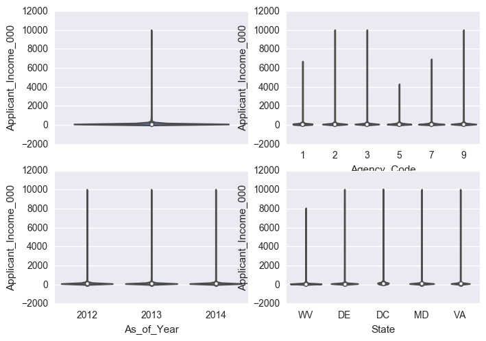

```python
plt.figure(1)
plt.subplot(221)
sns.violinplot(y = loan.Applicant_Income_000)
plt.subplot(222)
sns.violinplot(y = loan.Applicant_Income_000, x = loan.Agency_Code)
plt.subplot(223)
sns.violinplot(y = loan.Applicant_Income_000, x = loan.As_of_Year)
plt.subplot(224)
sns.violinplot(y = loan.Applicant_Income_000, x = loan.State)
plt.show()
```

```python
sum(loan.Applicant_Income_000 > 1000)
```

```
2500
```

- There are only 2,500 cases out of 1,321,158 (0.18%) where applicant income is greater than USD 1000k. We will cap the variable at USD 1000K

```python
# Capping applicant income at USD 1000k
loan.Applicant_Income_000 = [1000 if i>1000 else i for i in list(loan.Applicant_Income_000)]
```

#### Loan Amount:

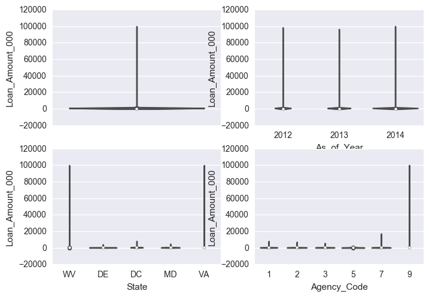

```python
plt.figure(1)
plt.subplot(221)
sns.violinplot(y = loan.Loan_Amount_000)
plt.subplot(222)
sns.violinplot(y = loan.Loan_Amount_000, x = loan.As_of_Year)
plt.subplot(223)
sns.violinplot(y = loan.Loan_Amount_000, x = loan.State)
plt.subplot(224)
sns.violinplot(y = loan.Loan_Amount_000, x = loan.Agency_Code)
plt.show()
```

```python
sum(loan.Loan_Amount_000>2000)
```

```
1340
```

```python
# Capping loan amount to 5000k:
loan.Loan_Amount_000 = [2000 if i>2000 else i for i in list(loan.Loan_Amount_000)]
```

### Institutions Data:

Lets Take a look at the institutions data. It is mentioned in the metadata that year, agency_code, respondent_id combination provides unique identifier for institution.

```python
a = pd.DataFrame(ins.groupby(['As_of_Year', 'Agency_Code']).Respondent_ID.apply(lambda x: len(set(x))))
a.reset_index(inplace = True)
a = pd.DataFrame(a.groupby('As_of_Year').Respondent_ID.sum())
a.reset_index(inplace = True)
a
```

|  | As_of_Year | Respondent_ID |
| --- | --- | --- |
| 0 | 2012 | 7401 |
| 1 | 2013 | 7191 |
| 2 | 2014 | 7063 |

```python
a = pd.DataFrame(ins.groupby('As_of_Year').Respondent_ID.count())
a.reset_index(inplace = True)
a
```

|  | As_of_Year | Respondent_ID |
| --- | --- | --- |
| 0 | 2012 | 7401 |
| 1 | 2013 | 7191 |
| 2 | 2014 | 7063 |

- There is unique observation in the instituition dataset for each unique combination of year, agency_code and respondent_id

```python
masterdata = loan.join(ins.set_index(['As_of_Year', 'Agency_Code', 'Respondent_ID']),
              how = 'left', on = ['As_of_Year', 'Agency_Code', 'Respondent_ID'] )

#masterdata.to_csv("masterdata.csv")
```

```python
a = pd.DataFrame(masterdata.groupby(['As_of_Year', 'Agency_Code']).Respondent_ID.apply(lambda x: len(set(x))))
a.reset_index(inplace = True)
a = pd.DataFrame(a.groupby('As_of_Year').Respondent_ID.sum())
a.reset_index(inplace = True)
a
```

|  | As_of_Year | Respondent_ID |
| --- | --- | --- |
| 0 | 2012 | 1314 |
| 1 | 2013 | 1133 |
| 2 | 2014 | 1012 |

- There are 1314, 1133 and 1012 unique institutions which reported the data under consideration in the years 2012, 2013 and 2014 respectively

```python
masterdata.Parent_Name_TS.describe()
```

```
count               595643
unique                 519
top       WELLS FARGO & CO
freq                119016
Name: Parent_Name_TS, dtype: object
```

- There are 519 unique parent institutions serving in the 5 states under consideration.

## Exploratory Analysis:

Our data corresponds to five states- 1) West Virginia, 2) Virginia, 3) District of Columbia, 4) Maryland and 4) Delaware for the years of 2012, 2013 and 2014. Let us have a glimpse of the demographics such as applicant income, loan amount and number of home loans etc., For the purpose of our analysis, we will use median applicant income and median loan amount, as there are significantly extreme outliers in our data (though capped).

- Median Income is not the median income of that MSA/ MD.

```python
plots = plotSummaryStateYear(loan)
show(row(plots['medianincome'], plots['medianamountlent']))
```

[interactive chart not shown]

#### Median Income and Amount lent :

```
From the above plots it is apparent that median applicant income and median loan amount are highly correlated with eachother as they follow the same trend across the states over the years. This is because both the fields are conseqences of the cost of living of that particular region. There is no significant change in median applicant income and median amount lent in all the states with time (period under consideration is very short). District of Columbia has the highest median income and amount lent followed by Maryland, Virginia, Delaware and West Virginia in that order.
```

```python
show(plots['noofloans'])
```

[interactive chart not shown]

#### Number of Loans:

```
Above plot shows the distribution of number of loans lent across the states. There is a significant drop in the number of loans across all the states. Virginia has most number of home loans followed by Maryland, West Virginia, Delaware and District of Columbia in that order. Although DC has highest median amount lent, number of loans is significantly lower. Maryland does better interms of both median loan amount and number of loans.
```

```python
show(row(plots['amountlentVSyear'], plots['Numberofloans']))
```

[interactive chart not shown]

#### Business Summary (Total Amount Lent) :

- Hover over sticks to find other characteristics such as median income, media loan amount and percentage chage in business from previous year

There is a drastic decrease in business i.e., total amount lent and also number of loans. There is a decrese of 17% from 2012 to 2013 and 35% from 2013 to 2014.

```python
show(gridplot([plots['marketshare_2012'], plots['marketshare_2013']], [plots['marketshare_2014'], None]))
```

[interactive chart not shown]

#### Market share(Percentage of total amount lent):

- Size of the circle represents median loan amount
- Transperancy of the circle represents median applicant income
- Please hover the cursor over the blobs to view other characteristics

The distribution of market share of the states does not vary much. As noticed earlier median income (transperancy) and median loan amount (size) are directly proportional. Virinia (around 50%) and Maryland (around 35%) contribute majorly to the market of home loans followed by District of Columbia, Delaware and West Virginia in that order.

```python
#Loan Type Summary (Conventional Vs Government Assured)
```

```python
plots = plotSummary(loan, 'Conventional_Status')
show(row(plots['year'], plots['state']))
```

[interactive chart not shown]

#### Loan type (Coneventional Vs Government Assured) Summary:

- There is no significant change in the distribution of conventional and non-conventional loan types in terms of total amount lent through 2012 to 2014. Majority of the market share is of conventional loans (around 70%)
- Each of the state's market except for DC, has around 70% contribution from convntional loans. Around 85% of DC's home loan aket is comprised of conventional loans

```python
show(row(plots['medianloanamount'], plots['medianincome'], plots['noofloansstate']))
```

[interactive chart not shown]

- Median loan amount is more or less same for both conventional and non-conventional loans
- Median applican income for conventional loans is a bit high for conventional loans across the states (May be government assistance is available for low-income applicants)
- As expected number of loans corresponding to conventional category is higher than non-conventional loans

```python
#Loan Purpose:
```

```python
plots = plotSummary(loan, "Loan_Purpose_Description")
show(row(plots['year'], plots['state']))
```

[interactive chart not shown]

#### Loan Purpose (Purchase or Refinance):

- There is a drastic shift in the home loan market during 2012 to 2014 in terms of the distribution of purchase and refinance loans. Refinance loans are on decline (their share plumetted from around 73% to 40%)
- There is no glaring difference in Purchase-Refinance loan distribution among different states.

```python
show(gridplot([plots['noofloansyear'], plots['amountlent'], plots['noofloansstate']],
              [plots['medianloanamount'], plots['medianincome'], None]))
```

[interactive chart not shown]

- From the above plot of Number of loans Vs Years, it can be noticed that while there is not much change in the number of purchase category loans, refinance loans declined from around 400k in 2012 to around 120k in 2014
- Home loan business i.e., in terms of total amount lent has not changed for purchase loans, but that of refinance loans has plumetted
- Decline in business can be attributed to decline in refinance loans

```python
# Lien Status Description
```

```python
plots = plotSummary(loan, 'Lien_Status_Description')
show(row(plots['year'], plots['state']))
```

[interactive chart not shown]

#### Lien Status (First Lien or Subordinate Lien):

- Almost 100% of the business is from loans of First-Lien category

```python
show(gridplot([plots['noofloansyear'], plots['amountlent'], plots['noofloansstate']],
              [plots['medianloanamount'], plots['medianincome'], None]))
```

[interactive chart not shown]

#### Summary of top 5 parent institutions:

```python
p1,r1 = plotParentSummaryyear(masterdata, 2012, 5)
interact(update1, year = (2012, 2014),  top = (1,10))
output_notebook()
```

```python
show(p1, notebook_handle = True)
```

[interactive chart not shown]

`<Bokeh Notebook handle for In[197]>`

- Please use the interact tool to view top institutions for diferent years
- Please hover over the circles to know more details about the institution
- Size of the circle indicates median loan amount
- Brightness of the circle indicates number of loans lent by the institution
- WELLS FARGO & CO is the top lender among all the states except for West Virginia
- Market-share of the top-players is on decline, showing increase in competition with time

#### County Heat-Map:

```python
p,r = countymap("totalloanamount", 2012)
interact(update2, year = (2012, 2014), column = ["noofloans", "medianloanamount", "totalloanamount", "medianincome"])
```

```python
show(p, notebook_handle = True)
```

[interactive chart not shown]

`<Bokeh Notebook handle for In[218]>`

- Please use the inetractor tool to select year and the variable of interest
- Above heat map shows the distribution of various parameters such as total amount lent, number of loans, median loan amount etc.,
- Please hover the county to find its details such as county name, state and the vale of the variable selected